# Week 2

David Kane

Go to https://registrar.fas.harvard.edu/faculty-staff/courses/enrollment and scroll down to “Access the Current Course Enrollment Numbers.” Click on that to download the Excel file. Create a folder in your project called `raw_data`. Move the Excel file into that folder. Be cool and do these things from the command line!

Load **tidyverse**, **readxl** and **janitor** into your setup chunk. You may need to install the packages **readxl** and **janitor** if you haven’t already.

### Scene 1

**Prompt:** Use **readxl** to read in the data and store it in an object called `raw`. Clean the data by cleaning any column names, skipping or cutting rows, and storing the cleaned data in an object called `en_fall_2020`. Additionally, since we will be looking only at undergraduate enrollment, get rid of any irrelevant columns, and filter to keep only courses with at least ten undergraduate students. This will get rid of any weird research courses. Look closely at your data! There is a lot of garbage to find and deal with.

Once you have finished cleaning your data, figure out the course with the highest enrollment. And figure out how many students are enrolled in Gov 50. If you get a number much lower than 151, you have done something wrong . . .

```r
raw <- read_xlsx('raw_data/enrollment.xlsx', skip = 3)
```

```r
en_fall_2020 <- raw %>%
  clean_names() %>%
  select(course_id, course_title, course_name, instructor_full_name, u_grad) %>%
  filter(course_title == "GOV 50", u_grad >= 10) %>%
  group_by(course_title) %>%
  summarize(summation = sum(u_grad, na.rm = T))
glimpse(en_fall_2020)
```

```
## Rows: 1
## Columns: 2
## $ course_title <chr> "GOV 50"
## $ summation    <dbl> 151
```

### Scene 2

**Prompt:** Create a bar plot of the 10 biggest courses. Order the plot so that courses appear in descending order. You will want to use coord_flip() to make your plot easy to read.

```r
biggest_10_courses <- raw %>%
  clean_names() %>%
  select(course_id, course_title, course_name, instructor_full_name, u_grad) %>%
  filter(u_grad >= 10) %>%
  group_by(course_title) %>%
  summarize(count = sum(u_grad, na.rm = T)) %>%
  drop_na() %>%
  arrange(desc(count)) %>%
  slice(1:10)
biggest_10_courses
```

```
## # A tibble: 10 x 2
##    course_title count
##    <chr>        <dbl>
##  1 ECON 10A       559
##  2 EXPOS 20       518
##  3 COMPSCI 50     504
##  4 GENED 1001     461
##  5 STAT 110       433
##  6 LIFESCI 1A     290
##  7 PSY 1          270
##  8 ECON 1010A     262
##  9 MATH 1B        253
## 10 GENED 1171     230
```

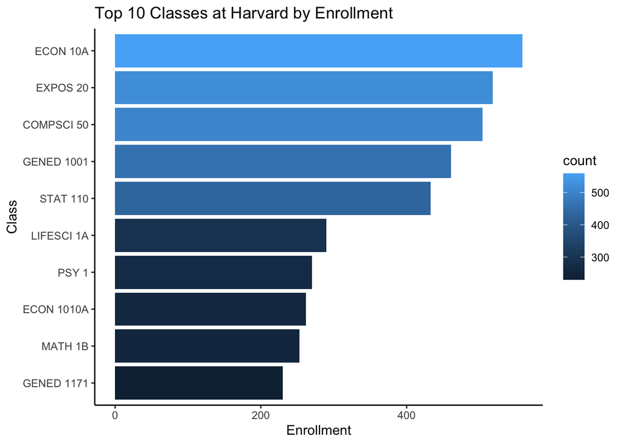

```r
biggest_10_courses %>%
  ggplot(mapping = aes(x = fct_reorder(as.factor(course_title), count),
                       y = count,
                       fill = count)) +
  geom_col() +
  coord_flip() +
  labs(x = "Class", y = "Enrollment", title = "Top 10 Classes at Harvard by Enrollment") +
  theme_classic()
```

### Scene 3

**Prompt:** Make a bar plot of total enrollment by department for the ten smallest departments. Arrange the bar plot in ascending order.

```r
smallest_10_depts <- raw %>%
  clean_names() %>%
  select(course_id, course_title, course_name, course_department, u_grad) %>%
  filter(u_grad >= 10) %>%
  group_by(course_department) %>%
  summarize(count = sum(u_grad, na.rm = T)) %>%
  drop_na() %>%
  arrange(count) %>%
  slice(1:10)
smallest_10_depts
```

```
## # A tibble: 10 x 2
##    course_department              count
##    <chr>                          <dbl>
##  1 Comparative Literature            10
##  2 Germanic Languages & Lit          10
##  3 Celtic Languages & Literatures    12
##  4 Theater, Dance & Media            12
##  5 South Asian Studies               13
##  6 Chemical & Physical Biology       17
##  7 Environmental Sci & Engineer      24
##  8 Biomedical Engineering            29
##  9 Earth & Planetary Sciences        29
## 10 Near Eastern Languages & Civ      37
```

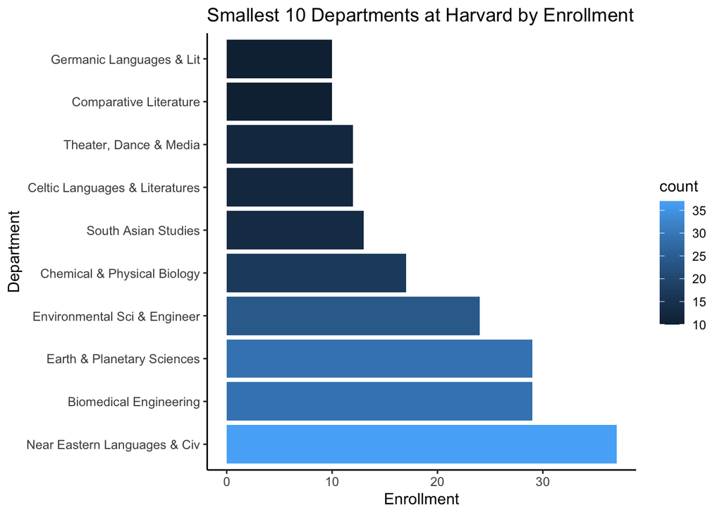

```r
smallest_10_depts %>%
  ggplot(mapping = aes(x = fct_reorder(as.factor(course_department), desc(count)),
                       y = count,
                       fill = count)) +
  geom_col() +
  coord_flip() +
  labs(x = "Department", y = "Enrollment", title = "Smallest 10 Departments at Harvard by Enrollment") +
  theme_classic()
```

### Scene 4

**Prompt:** Create a scatterplot of the length of course name versus enrollment for the Computer Science and Economics Department. Use `nchar()` to find the length, and include spaces. Add a linear line of best fit on your plot and scale axes appropriately.

```r
ec_cs <- raw %>%
  clean_names() %>%
  select(course_title, course_name, course_department, u_grad) %>%
  filter(str_detect(course_title, "COMPSCI") | str_detect(course_title, "ECON")) %>%
  filter(u_grad >= 10) %>%
  mutate(course_name = str_trim(course_name, side = "both")) %>%
  group_by(course_name) %>%
  summarize(title_length = max(nchar(course_name)), enroll = sum(u_grad), dpt = course_department)
```

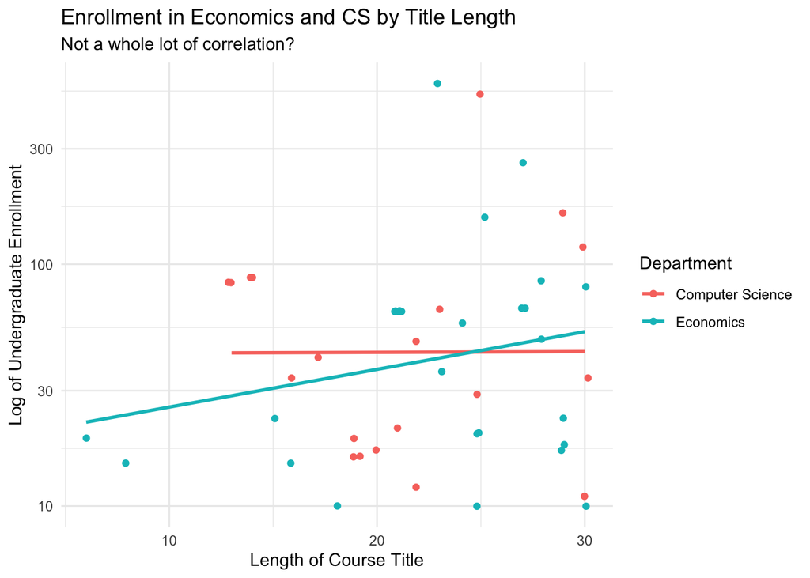

```r
ec_cs %>%
  ggplot(mapping = aes(x = title_length, y = enroll, color = dpt)) +
  geom_jitter(width = 0.2) +
  geom_smooth(se = F, method = "lm") +
  labs(x = "Length of Course Title",
       y = "Log of Undergraduate Enrollment",
       title = "Enrollment in Economics and CS by Title Length",
       subtitle = "Not a whole lot of correlation?") +
  scale_y_log10() +
  scale_color_discrete(name = "Department") +
  theme_minimal()
```